# AdaBoost for Regression

AdaBoost.R2 with one input variable

Son Nguyen

## What you will learn

By the end of this session you can:

1. Explain **why** combining many weak learners can beat one strong-looking learner
2. Run **one round** of AdaBoost.R2 by hand: weights → stump → loss → voting power → new weights
3. Say what the learning rate $\eta$ does
4. Build the final prediction as a **weighted median** of the stumps
5. Spot when AdaBoost.R2 stops or struggles (e.g. $\bar L \ge 0.5$, outliers)

## Why boosting? One stump is too simple

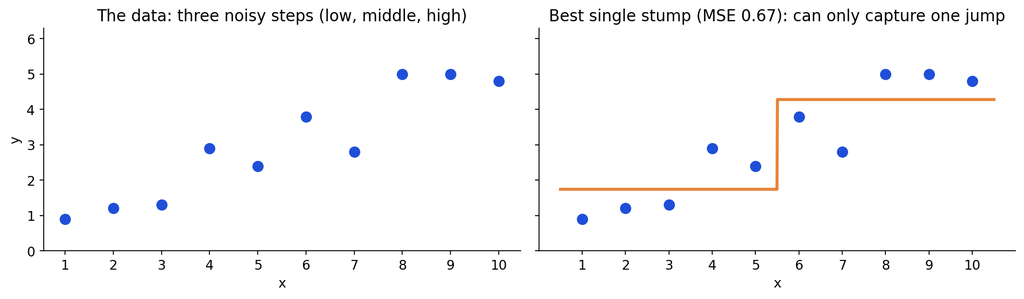

- A stump is a **weak learner**: two flat pieces, easy to fit, clearly too simple
- **Boosting idea:** fit a stump, look at where it is wrong, then build the next stump to *care more* about those points

**Think:** where would you put a second stump so that the two together capture all three steps? (Hold that thought. AdaBoost will answer it for us.)

## Idea Behind AdaBoost

- Examples of **high weight** are shown more often at later rounds
- In classification, “high weight” means *misclassified*. In regression there is no right/wrong, so **high weight = large error**
- Regression problem: predict a continuous $y$ from a single input $x$

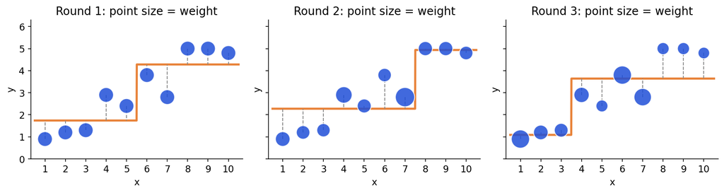

- Dashed lines are the errors of that round’s stump. The bigger the error, the bigger the point in the next round

## The big picture: one loop, repeated

**1. Weights**  
start equal: 1/n

→

**2. Fit a stump**  
using the weights

→

**3. Measure errors**  
loss L<sub>i</sub> between 0 and 1

→

**4. Voting power α**  
small avg loss ⇒ big α

→

**5. Update weights**  
hard rows get relatively more

↺

- After $M$ rounds we keep **all** stumps. Prediction = **weighted median** of their outputs, where trustworthy stumps (large $\alpha$) count more

## Classification vs. Regression

|  | AdaBoost (classification) | AdaBoost.R2 (regression) |
| --- | --- | --- |
| Weak learner | Stump predicting $\pm 1$ | Regression stump (predicts a mean) |
| Split criterion | Weighted Gini index | Weighted sum of squared errors |
| Mistake? | Wrong class: yes / no | Size of the error: $0 \le L_i \le 1$ |
| Total error | Sum of weights of the wrong rows | Weighted average loss $\bar L=\sum w_iL_i$ |
| Final model | Sign of weighted vote | **Weighted median** of the stump predictions |

- Assumption: there is always a weak learner that is better than “chance”, i.e. $\bar L < 0.5$

## The AdaBoost.R2 Algorithm

Start with $w_i = 1/n$. For rounds $m = 1, \dots, M$:

1. Fit a stump $h_m$ using the weights $w_i$ (weighted SSE)
2. Largest error: $D_m = \max_i |y_i - h_m(x_i)|$
3. Loss of each row (square loss): $L_i = \left(\dfrac{|y_i - h_m(x_i)|}{D_m}\right)^2 \in [0,1]$
4. Average loss: $\bar L_m = \sum_i w_i L_i$ (stop if $\bar L_m \ge 0.5$)
5. $\beta_m = \dfrac{\bar L_m}{1-\bar L_m}$, voting power $\alpha_m = \eta \cdot \ln\dfrac{1}{\beta_m}$ ($\eta$ is the learning rate)
6. New weights: $w_i \leftarrow w_i\,\beta_m^{\,\eta(1-L_i)}$, then divide by the total so they sum to 1

Final model: $H(x) = $ weighted median of $h_1(x),\dots,h_M(x)$ with weights $\alpha_1,\dots,\alpha_M$

## Reading the formulas: three pictures

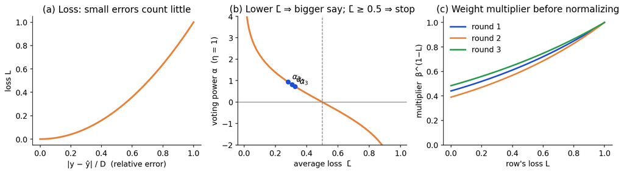

- 1. A row with the **largest** error has $L=1$; others are scaled relative to it
- 2. $\alpha$ is the log-odds of being “good”: $\ln\frac{1-\bar L}{\bar L}$
- 3. Every multiplier is $\le 1$, but **bad rows keep more** of their weight ($L=1 \Rightarrow$ multiplier 1). After normalizing, bad rows go **up**

## Adaboost, Clearly Explained

# Calculation Example

## Calculation Example

Data

| x | y |
| --- | --- |
| 1 | 0.9 |
| 2 | 1.2 |
| 3 | 1.3 |
| 4 | 2.9 |
| 5 | 2.4 |
| 6 | 3.8 |
| 7 | 2.8 |
| 8 | 5.0 |
| 9 | 5.0 |
| 10 | 4.8 |

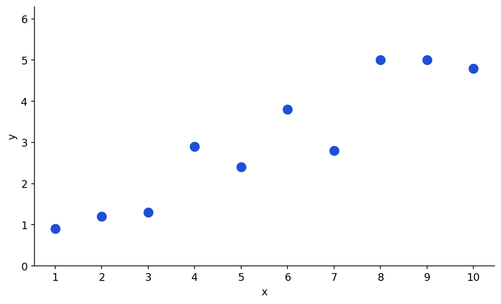

## Adaboost in a nutshell

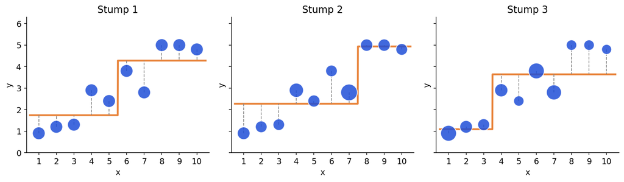

- Each stump is a step function with 2 levels
- Later stumps focus on the points the earlier stumps fit poorly

## Make Stump 1

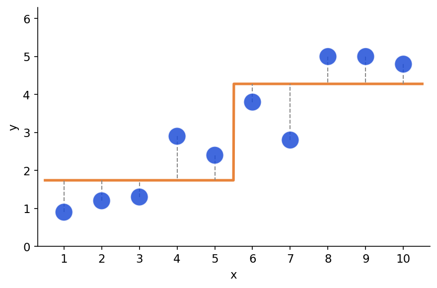

## Make Stump 2

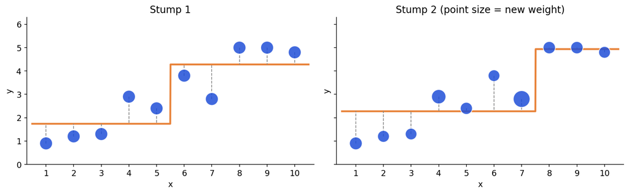

## Make Stump 3

**Voting power:** $\alpha_1 = 0.819$ $\alpha_2 = 0.942$ $\alpha_3 = 0.726$

Final model: $H(x) = \text{weighted median}\,[\,h_1(x),\,h_2(x),\,h_3(x)\,]$ with weights $\alpha_1,\alpha_2,\alpha_3$

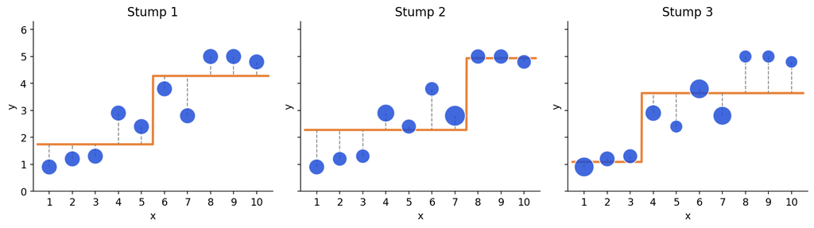

## Combine the Stumps

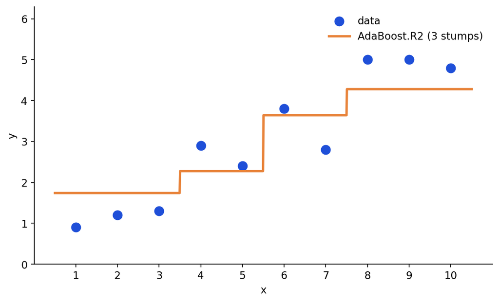

# Detail Calculation

## Make the first stump

Assign weights for each row. Every row has the same weight in the first step: $w_i = 1/n = 0.1$

| Row | x | y | Weight 1 |
| --- | --- | --- | --- |
| 0 | 1 | 0.9 | 0.1 |
| 1 | 2 | 1.2 | 0.1 |
| 2 | 3 | 1.3 | 0.1 |
| 3 | 4 | 2.9 | 0.1 |
| 4 | 5 | 2.4 | 0.1 |
| 5 | 6 | 3.8 | 0.1 |
| 6 | 7 | 2.8 | 0.1 |
| 7 | 8 | 5.0 | 0.1 |
| 8 | 9 | 5.0 | 0.1 |
| 9 | 10 | 4.8 | 0.1 |

## Make the first stump

- Evaluate **every candidate split** (midpoints between consecutive $x$ values)
- In each child the prediction is the **weighted mean** of $y$; the impurity is the **weighted sum of squared errors** (SSE)
- The split with the lowest SSE is the best split

| Split: x ≤ | Left mean | Right mean | Weighted SSE |
| --- | --- | --- | --- |
| 1.5 | 0.9000 | 3.2444 | 1.7882 |
| 2.5 | 1.0500 | 3.5000 | 1.3225 |
| 3.5 | 1.1333 | 3.8143 | 0.7735 |
| 4.5 | 1.5750 | 3.9667 | 0.9101 |
| 5.5 | 1.7400 | 4.2800 | **0.67** |
| 6.5 | 2.0833 | 4.4000 | 0.9948 |
| 7.5 | 2.1857 | 4.9333 | 0.6975 |
| 8.5 | 2.5375 | 4.9000 | 1.3899 |
| 9.5 | 2.8111 | 4.8000 | 1.9269 |

## Make the first stump

Stump 1: split at the best threshold; predict the left mean on the left and the right mean on the right

- If $x \le 5.5$, predicts $1.740$

- Otherwise, predicts $4.280$

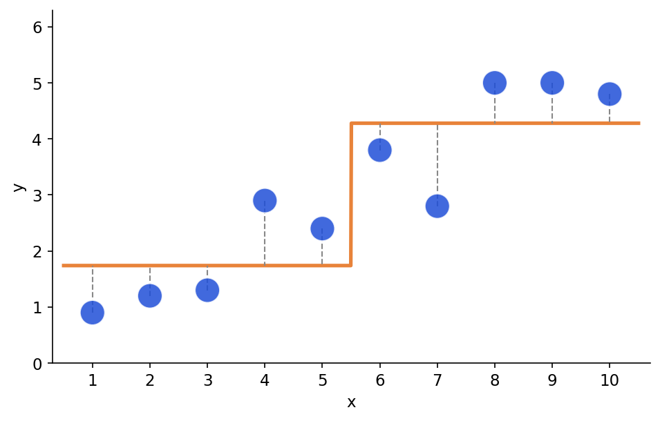

## Prediction of Stump 1

| Row | x | y | Weight 1 | Stump 1 Predicts |
| --- | --- | --- | --- | --- |
| 0 | 1 | 0.9 | 0.1 | 1.74 |
| 1 | 2 | 1.2 | 0.1 | 1.74 |
| 2 | 3 | 1.3 | 0.1 | 1.74 |
| 3 | 4 | 2.9 | 0.1 | 1.74 |
| 4 | 5 | 2.4 | 0.1 | 1.74 |
| 5 | 6 | 3.8 | 0.1 | 4.28 |
| 6 | 7 | 2.8 | 0.1 | 4.28 |
| 7 | 8 | 5.0 | 0.1 | 4.28 |
| 8 | 9 | 5.0 | 0.1 | 4.28 |
| 9 | 10 | 4.8 | 0.1 | 4.28 |

## Error of the first stump

Unlike classification there is no right/wrong. We measure **how far** each prediction is from $y$.

| Row | x | y | Weight 1 | Stump 1 Predicts | \|y − ŷ\| |
| --- | --- | --- | --- | --- | --- |
| 0 | 1 | 0.9 | 0.1 | 1.74 | 0.84 |
| 1 | 2 | 1.2 | 0.1 | 1.74 | 0.54 |
| 2 | 3 | 1.3 | 0.1 | 1.74 | 0.44 |
| 3 | 4 | 2.9 | 0.1 | 1.74 | 1.16 |
| 4 | 5 | 2.4 | 0.1 | 1.74 | 0.66 |
| 5 | 6 | 3.8 | 0.1 | 4.28 | 0.48 |
| 6 | 7 | 2.8 | 0.1 | 4.28 | 1.48 ← D |
| 7 | 8 | 5.0 | 0.1 | 4.28 | 0.72 |
| 8 | 9 | 5.0 | 0.1 | 4.28 | 0.72 |
| 9 | 10 | 4.8 | 0.1 | 4.28 | 0.52 |

## Error of the first stump

The largest error is $D_1 = \max_i |y_i - \hat y_i| = 1.480$ (row 6). Loss of each row:

$$L_i = \left(\frac{|y_i - \hat y_i|}{D_1}\right)^2$$

| Row | x | y | Weight 1 | \|y − ŷ\| | Loss L | w · L |
| --- | --- | --- | --- | --- | --- | --- |
| 0 | 1 | 0.9 | 0.1 | 0.84 | 0.3221 | 0.03221 |
| 1 | 2 | 1.2 | 0.1 | 0.54 | 0.1331 | 0.01331 |
| 2 | 3 | 1.3 | 0.1 | 0.44 | 0.0884 | 0.00884 |
| 3 | 4 | 2.9 | 0.1 | 1.16 | 0.6143 | 0.06143 |
| 4 | 5 | 2.4 | 0.1 | 0.66 | 0.1989 | 0.01989 |
| 5 | 6 | 3.8 | 0.1 | 0.48 | 0.1052 | 0.01052 |
| 6 | 7 | 2.8 | 0.1 | 1.48 | 1.0000 | 0.10000 |
| 7 | 8 | 5.0 | 0.1 | 0.72 | 0.2367 | 0.02367 |
| 8 | 9 | 5.0 | 0.1 | 0.72 | 0.2367 | 0.02367 |
| 9 | 10 | 4.8 | 0.1 | 0.52 | 0.1234 | 0.01234 |

## Total error and voting power of Stump 1

Average loss (the analogue of $\epsilon_1$):
$$\bar L_1 = \sum_i w_i L_i = 0.3059$$

$$\beta_1 = \frac{\bar L_1}{1-\bar L_1} = 0.4407$$

Voting power ($\eta$ is the learning rate, in this example $\eta=1$):
$$\alpha_1 = \eta \cdot \ln\frac{1}{\beta_1} = 0.819$$

## Pause and predict

Before we compute the new weights: looking at the residual plot of Stump 1, **which rows do you expect to gain weight?** Which lose?

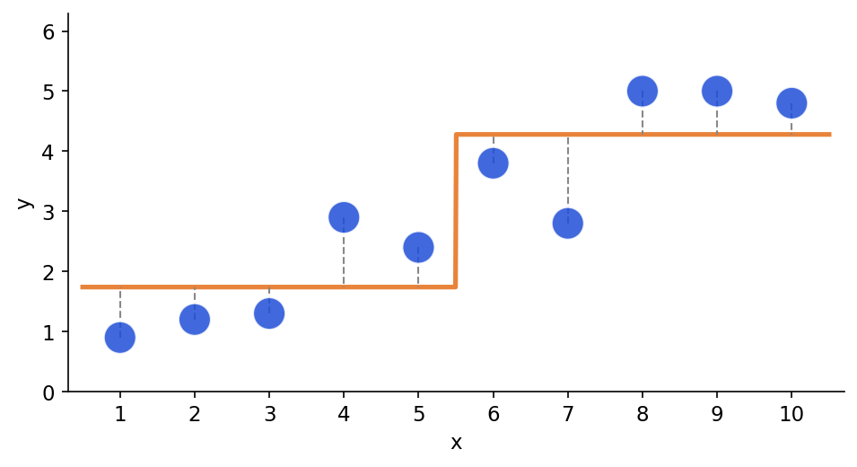

Rows with the longest dashed lines (largest error) should gain weight; rows sitting on the orange line should lose weight.

## Calculating the new weights

$$w_{new} = w_{old} \cdot \beta_1^{\,\eta\,(1 - L_i)}$$

- Row 6 (largest loss, $L=1.000$): $0.1000 \cdot 0.4407^{(1-1.000)} = 0.1000$

- Row 2 (smallest loss, $L=0.088$): $0.1000 \cdot 0.4407^{(1-0.088)} = 0.0474$

| Row | x | y | Weight 1 | Loss L | Weight 2 (raw) |
| --- | --- | --- | --- | --- | --- |
| 0 | 1 | 0.9 | 0.1 | 0.3221 | 0.0574 |
| 1 | 2 | 1.2 | 0.1 | 0.1331 | 0.0491 |
| 2 | 3 | 1.3 | 0.1 | 0.0884 | 0.0474 |
| 3 | 4 | 2.9 | 0.1 | 0.6143 | 0.0729 |
| 4 | 5 | 2.4 | 0.1 | 0.1989 | 0.0519 |
| 5 | 6 | 3.8 | 0.1 | 0.1052 | 0.0480 |
| 6 | 7 | 2.8 | 0.1 | 1.0000 | 0.1000 |
| 7 | 8 | 5.0 | 0.1 | 0.2367 | 0.0535 |
| 8 | 9 | 5.0 | 0.1 | 0.2367 | 0.0535 |
| 9 | 10 | 4.8 | 0.1 | 0.1234 | 0.0488 |

## Calculating the new weights

The total weights have to be 1. We divide the weights by the total to achieve this.

Total of raw Weight 2 $= 0.5825$ → divide Weight 2 by $0.5825$

| Row | x | y | Weight 1 | Weight 2 (raw) | Weight 2 |
| --- | --- | --- | --- | --- | --- |
| 0 | 1 | 0.9 | 0.1 | 0.0574 | 0.0985 |
| 1 | 2 | 1.2 | 0.1 | 0.0491 | 0.0844 |
| 2 | 3 | 1.3 | 0.1 | 0.0474 | 0.0813 |
| 3 | 4 | 2.9 | 0.1 | 0.0729 | 0.1252 |
| 4 | 5 | 2.4 | 0.1 | 0.0519 | 0.0890 |
| 5 | 6 | 3.8 | 0.1 | 0.0480 | 0.0825 |
| 6 | 7 | 2.8 | 0.1 | 0.1000 | 0.1717 |
| 7 | 8 | 5.0 | 0.1 | 0.0535 | 0.0918 |
| 8 | 9 | 5.0 | 0.1 | 0.0535 | 0.0918 |
| 9 | 10 | 4.8 | 0.1 | 0.0488 | 0.0837 |

# Repeat the process to make the second Stump

## Data to make the second stump

| Row | x | y | Weight 2 |
| --- | --- | --- | --- |
| 0 | 1 | 0.9 | 0.0985 |
| 1 | 2 | 1.2 | 0.0844 |
| 2 | 3 | 1.3 | 0.0813 |
| 3 | 4 | 2.9 | 0.1252 |
| 4 | 5 | 2.4 | 0.0890 |
| 5 | 6 | 3.8 | 0.0825 |
| 6 | 7 | 2.8 | 0.1717 |
| 7 | 8 | 5.0 | 0.0918 |
| 8 | 9 | 5.0 | 0.0918 |
| 9 | 10 | 4.8 | 0.0837 |

## Make the second stump

- Use weighted SSE to evaluate all candidate splits, using **Weight 2**
- The split with the lowest weighted SSE is the best split

| Split: x ≤ | Left mean | Right mean | Weighted SSE |
| --- | --- | --- | --- |
| 1.5 | 0.9000 | 3.2148 | 1.5658 |
| 2.5 | 1.0384 | 3.4228 | 1.1921 |
| 3.5 | 1.1189 | 3.6575 | 0.7888 |
| 4.5 | 1.6914 | 3.8128 | 0.9717 |
| 5.5 | 1.8233 | 4.0540 | 0.8 |
| 6.5 | 2.1139 | 4.1017 | 1.0686 |
| 7.5 | 2.2747 | 4.9374 | **0.6528** |
| 8.5 | 2.5783 | 4.9046 | 1.2584 |
| 9.5 | 2.8211 | 4.8000 | 1.7413 |

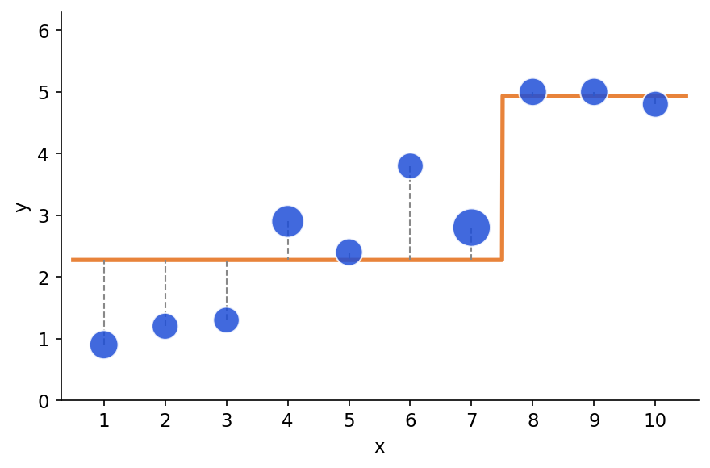

## Error of the second stump

| Row | x | y | Weight 2 | Stump 2 Predicts | \|y − ŷ\| | Loss L |
| --- | --- | --- | --- | --- | --- | --- |
| 0 | 1 | 0.9 | 0.0985 | 2.275 | 1.375 | 0.8123 |
| 1 | 2 | 1.2 | 0.0844 | 2.275 | 1.075 | 0.4965 |
| 2 | 3 | 1.3 | 0.0813 | 2.275 | 0.975 | 0.4084 |
| 3 | 4 | 2.9 | 0.1252 | 2.275 | 0.625 | 0.1681 |
| 4 | 5 | 2.4 | 0.0890 | 2.275 | 0.125 | 0.0067 |
| 5 | 6 | 3.8 | 0.0825 | 2.275 | 1.525 | 1.0000 |
| 6 | 7 | 2.8 | 0.1717 | 2.275 | 0.525 | 0.1186 |
| 7 | 8 | 5.0 | 0.0918 | 4.937 | 0.063 | 0.0017 |
| 8 | 9 | 5.0 | 0.0918 | 4.937 | 0.063 | 0.0017 |
| 9 | 10 | 4.8 | 0.0837 | 4.937 | 0.137 | 0.0081 |

$D_2 = 1.525$ $\bar L_2 = \sum_i w_iL_i = 0.2806$ $\beta_2 = 0.3900$

Voting power: $\alpha_2 = \eta\ln\dfrac{1}{\beta_2} = 0.942$

## Calculating the new weights (Stump 2)

$$w_{new} = w_{old} \cdot \beta_2^{\,\eta\,(1 - L_i)} \qquad\text{then normalize}$$

| Row | x | y | Weight 2 | Loss L | Weight 3 (raw) | Weight 3 |
| --- | --- | --- | --- | --- | --- | --- |
| 0 | 1 | 0.9 | 0.0985 | 0.8123 | 0.08255 | 0.15408 |
| 1 | 2 | 1.2 | 0.0844 | 0.4965 | 0.05252 | 0.09802 |
| 2 | 3 | 1.3 | 0.0813 | 0.4084 | 0.04660 | 0.08697 |
| 3 | 4 | 2.9 | 0.1252 | 0.1681 | 0.05718 | 0.10673 |
| 4 | 5 | 2.4 | 0.0890 | 0.0067 | 0.03495 | 0.06523 |
| 5 | 6 | 3.8 | 0.0825 | 1.0000 | 0.08247 | 0.15391 |
| 6 | 7 | 2.8 | 0.1717 | 0.1186 | 0.07487 | 0.13973 |
| 7 | 8 | 5.0 | 0.0918 | 0.0017 | 0.03588 | 0.06696 |
| 8 | 9 | 5.0 | 0.0918 | 0.0017 | 0.03588 | 0.06696 |
| 9 | 10 | 4.8 | 0.0837 | 0.0081 | 0.03290 | 0.06140 |

Total of raw Weight 3 $= 0.535799$

# Repeat the process to make the third Stump

## Data to make the third stump

| Row | x | y | Weight 3 |
| --- | --- | --- | --- |
| 0 | 1 | 0.9 | 0.1541 |
| 1 | 2 | 1.2 | 0.0980 |
| 2 | 3 | 1.3 | 0.0870 |
| 3 | 4 | 2.9 | 0.1067 |
| 4 | 5 | 2.4 | 0.0652 |
| 5 | 6 | 3.8 | 0.1539 |
| 6 | 7 | 2.8 | 0.1397 |
| 7 | 8 | 5.0 | 0.0670 |
| 8 | 9 | 5.0 | 0.0670 |
| 9 | 10 | 4.8 | 0.0614 |

## Make the third stump

- Use weighted SSE to evaluate all candidate splits, using **Weight 3**
- The split with the lowest weighted SSE is the best split

| Split: x ≤ | Left mean | Right mean | Weighted SSE |
| --- | --- | --- | --- |
| 1.5 | 0.9000 | 3.1176 | 1.4205 |
| 2.5 | 1.0166 | 3.3689 | 1.0182 |
| 3.5 | 1.0893 | 3.6411 | **0.6022** |
| 4.5 | 1.5228 | 3.7839 | 0.7984 |
| 5.5 | 1.6348 | 3.9685 | 0.7006 |
| 6.5 | 2.1360 | 4.0459 | 1.2488 |
| 7.5 | 2.2513 | 4.9371 | 0.9277 |
| 8.5 | 2.4625 | 4.9043 | 1.3943 |
| 9.5 | 2.6435 | 4.8000 | 1.7935 |

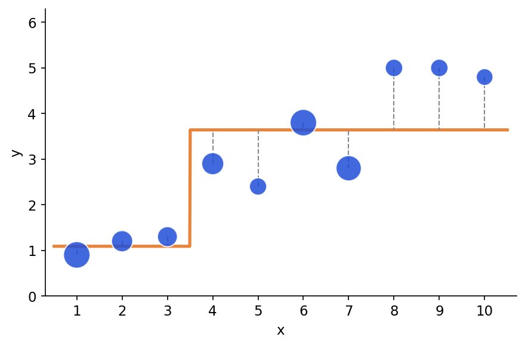

## Error of the third stump

| Row | x | y | Weight 3 | Stump 3 Predicts | \|y − ŷ\| | Loss L |
| --- | --- | --- | --- | --- | --- | --- |
| 0 | 1 | 0.9 | 0.1541 | 1.089 | 0.189 | 0.0194 |
| 1 | 2 | 1.2 | 0.0980 | 1.089 | 0.111 | 0.0066 |
| 2 | 3 | 1.3 | 0.0870 | 1.089 | 0.211 | 0.0240 |
| 3 | 4 | 2.9 | 0.1067 | 3.641 | 0.741 | 0.2975 |
| 4 | 5 | 2.4 | 0.0652 | 3.641 | 1.241 | 0.8342 |
| 5 | 6 | 3.8 | 0.1539 | 3.641 | 0.159 | 0.0137 |
| 6 | 7 | 2.8 | 0.1397 | 3.641 | 0.841 | 0.3832 |
| 7 | 8 | 5.0 | 0.0670 | 3.641 | 1.359 | 1.0000 |
| 8 | 9 | 5.0 | 0.0670 | 3.641 | 1.359 | 1.0000 |
| 9 | 10 | 4.8 | 0.0614 | 3.641 | 1.159 | 0.7273 |

$D_3 = 1.359$ $\bar L_3 = \sum_i w_iL_i = 0.3261$ $\beta_3 = 0.4840$

Voting power: $\alpha_3 = \eta\ln\dfrac{1}{\beta_3} = 0.726$

## Summarise the results

| Row | x | y | Weight 1 | Stump 1 Predicts | Weight 2 | Stump 2 Predicts | Weight 3 | Stump 3 Predicts |
| --- | --- | --- | --- | --- | --- | --- | --- | --- |
| 0 | 1 | 0.9 | 0.1 | 1.74 | 0.0985 | 2.275 | 0.1541 | 1.089 |
| 1 | 2 | 1.2 | 0.1 | 1.74 | 0.0844 | 2.275 | 0.0980 | 1.089 |
| 2 | 3 | 1.3 | 0.1 | 1.74 | 0.0813 | 2.275 | 0.0870 | 1.089 |
| 3 | 4 | 2.9 | 0.1 | 1.74 | 0.1252 | 2.275 | 0.1067 | 3.641 |
| 4 | 5 | 2.4 | 0.1 | 1.74 | 0.0890 | 2.275 | 0.0652 | 3.641 |
| 5 | 6 | 3.8 | 0.1 | 4.28 | 0.0825 | 2.275 | 0.1539 | 3.641 |
| 6 | 7 | 2.8 | 0.1 | 4.28 | 0.1717 | 2.275 | 0.1397 | 3.641 |
| 7 | 8 | 5.0 | 0.1 | 4.28 | 0.0918 | 4.937 | 0.0670 | 3.641 |
| 8 | 9 | 5.0 | 0.1 | 4.28 | 0.0918 | 4.937 | 0.0670 | 3.641 |
| 9 | 10 | 4.8 | 0.1 | 4.28 | 0.0837 | 4.937 | 0.0614 | 3.641 |

$\alpha_1 = 0.819$ $\alpha_2 = 0.942$ $\alpha_3 = 0.726$

## How the weights evolve

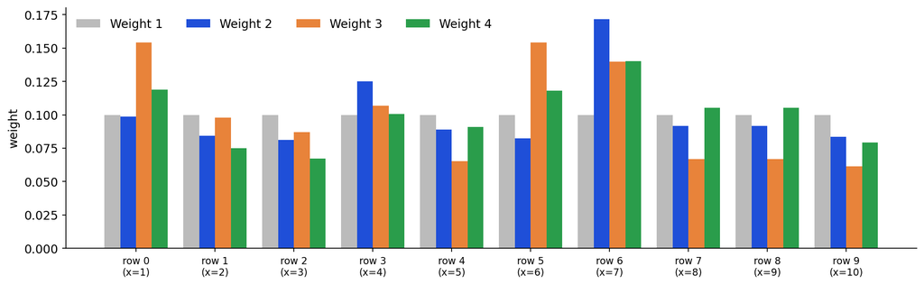

- Rows that no stump fits well keep growing; rows that every stump fits shrink
- Rows near the step edges (hard to fit with one split) end up with the most weight

## Combining three Stumps

- Let’s say we stop making new stumps here
- Final model $H(x)$ = **weighted median** of the stump predictions, using the voting powers $\alpha_m$ as weights

**Recipe for one input value $x_0$:**

1. Get the three predictions $h_1(x_0), h_2(x_0), h_3(x_0)$
2. Sort them from smallest to largest
3. Add up the voting powers in that order until the running total reaches half of $\alpha_1+\alpha_2+\alpha_3$
4. The prediction at which that happens is $H(x_0)$

## Combining three Stumps: example

Take row 6: $x = 7$ (true $y = 2.8$). Half of the total voting power is $1.243$.

| Sorted prediction | From stump | Voting power | Cumulative |
| --- | --- | --- | --- |
| 2.275 | Stump 2 | 0.942 | 0.942 |
| 3.641 | Stump 3 | 0.726 | 1.667 |
| 4.280 | Stump 1 | 0.819 | 2.487 |

First cumulative value $\ge 1.243$ → $H(7) = 3.641$

## Combining three Stumps: all rows

| Row | x | y | Stump 1 | Stump 2 | Stump 3 | H(x) | y − H(x) |
| --- | --- | --- | --- | --- | --- | --- | --- |
| 0 | 1 | 0.9 | 1.74 | 2.275 | 1.089 | 1.740 | -0.840 |
| 1 | 2 | 1.2 | 1.74 | 2.275 | 1.089 | 1.740 | -0.540 |
| 2 | 3 | 1.3 | 1.74 | 2.275 | 1.089 | 1.740 | -0.440 |
| 3 | 4 | 2.9 | 1.74 | 2.275 | 3.641 | 2.275 | 0.625 |
| 4 | 5 | 2.4 | 1.74 | 2.275 | 3.641 | 2.275 | 0.125 |
| 5 | 6 | 3.8 | 4.28 | 2.275 | 3.641 | 3.641 | 0.159 |
| 6 | 7 | 2.8 | 4.28 | 2.275 | 3.641 | 3.641 | -0.841 |
| 7 | 8 | 5.0 | 4.28 | 4.937 | 3.641 | 4.280 | 0.720 |
| 8 | 9 | 5.0 | 4.28 | 4.937 | 3.641 | 4.280 | 0.720 |
| 9 | 10 | 4.8 | 4.28 | 4.937 | 3.641 | 4.280 | 0.520 |

MSE of Stump 1 alone: $0.670$ → MSE of the 3-stump model: $0.364$

## Combining three Stumps

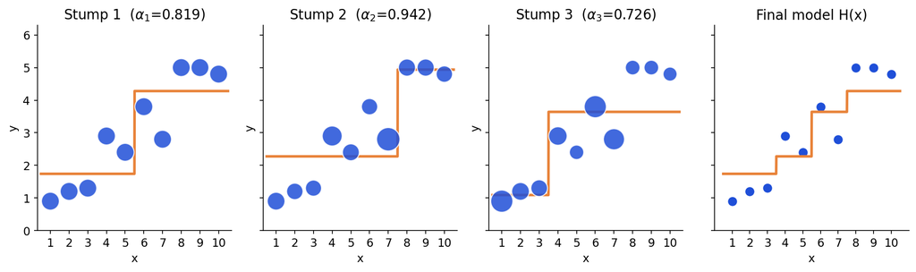

## Adding stumps one at a time

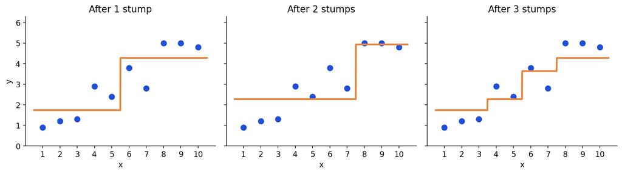

## More stumps = better fit?

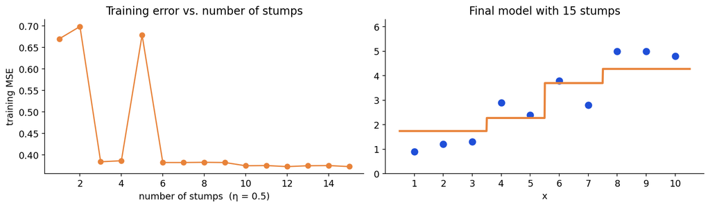

- Training error drops quickly in the first few rounds, then levels off (it can wobble, because the weighted median can switch which stump it follows)
- With many stumps an ensemble can **overfit**: choose the number of stumps and $\eta$ with a validation set

## Learning rate

- The learning rate $\eta$ scales both the voting power and the weight update:
  $$\alpha_m = \eta\ln\frac{1}{\beta_m}, \qquad w_i \leftarrow w_i\,\beta_m^{\,\eta(1-L_i)}$$
- A smaller $\eta$ changes the weights more slowly, so you need **more stumps**

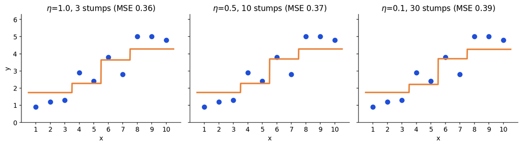

## Common pitfalls

- **$\bar L_m \ge 0.5$:** the stump is no better than “chance” ⇒ $\alpha \le 0$, so we **stop** boosting
- **One outlier:** its error is huge, so it keeps gaining weight and later stumps chase it. AdaBoost.R2 is sensitive to outliers (the loss is scaled by $D$, the maximum error)
- **Weights only matter relatively:** raw weights shrink every round; the normalization step is what makes them comparable
- **Median, not mean:** the weighted median is robust to one bad stump; a weighted average is not

## Check your understanding

**Q1.** A stump has average loss $\bar L = 0.5$. What are $\beta$ and $\alpha$? What should we do?

$\beta = 0.5/0.5 = 1$, $\alpha=\ln 1 = 0$. The stump has no voting power; we stop.

**Q2.** In round 2 a row has loss $L=1$ (the worst row). By what factor is its **raw** weight multiplied before normalizing?

$\beta^{\eta(1-L)} = \beta^{0} = 1$: unchanged, but everything else shrinks, so after normalizing it goes **up**.

## Practice problem (do it by hand)

A stump has average loss $\bar L = 0.2$ (learning rate $\eta=1$).

1. Compute $\beta$ and $\alpha$.
2. A row currently has weight $0.10$ and loss $L=0.25$. What is its raw new weight?
3. Three stumps predict $2,\ 3,\ 5$ at some $x_0$ with voting powers $0.5,\ 1.0,\ 0.4$. What is $H(x_0)$?

1. $\beta = 0.2/0.8 = 0.25$, $\alpha = \ln 4 = 1.386$

2. $0.10 \cdot 0.25^{0.75} = 0.0354$

3. Sorted: $2\,(0.5),\ 3\,(1.0),\ 5\,(0.4)$. Half of $1.9$ is $0.95$; cumulative $0.5,\ 1.5$ ⇒ $H(x_0)=3$

## Cheat sheet

| Step | Formula |
| --- | --- |
| Start | $w_i = 1/n$ |
| Stump | split minimizing weighted SSE; leaf value = weighted mean of $y$ |
| Max error | $D = \max_i \lvert y_i-\hat y_i\rvert$ |
| Loss | $L_i = (\lvert y_i-\hat y_i\rvert / D)^2$ |
| Average loss | $\bar L = \sum_i w_iL_i$ (need $<0.5$) |
| Ratio | $\beta = \bar L / (1-\bar L)$ |
| Voting power | $\alpha = \eta \ln(1/\beta)$ |
| New weights | $w_i \leftarrow w_i\,\beta^{\eta(1-L_i)}$, then normalize |
| Prediction | weighted median of the stumps, weights $\alpha_m$ |

## Summary

- AdaBoost.R2 builds a sequence of regression stumps; each one is fit on **re-weighted** data
- Rows with a **large error** get relatively more weight in the next round
- Each stump’s **voting power** $\alpha_m=\eta\ln\frac{1}{\beta_m}$ depends on its average loss $\bar L_m$
- The final prediction is the **weighted median** of all stumps
- Smaller learning rate ⇒ slower learning, more stumps needed